# [과제4] 임원기

lim wonki

2019. 6. 10

## 사전 준비

```r
library(dplyr)
```

```r
library(ggplot2)
```

### **R 연습문제**

- **문제 1) 데이터의 cty(도시 연비)와 hwy(고속도로 연비) 간에 어떤 관계가 있는지 알아보려고 합니다. x축은 cty, y축은 hwy로 된 산점도를 만들어 보세요.**

```r
str(mpg)
```

```
## Classes 'tbl_df', 'tbl' and 'data.frame':    234 obs. of  11 variables:
##  $ manufacturer: chr  "audi" "audi" "audi" "audi" ...
##  $ model       : chr  "a4" "a4" "a4" "a4" ...
##  $ displ       : num  1.8 1.8 2 2 2.8 2.8 3.1 1.8 1.8 2 ...
##  $ year        : int  1999 1999 2008 2008 1999 1999 2008 1999 1999 2008 ...
##  $ cyl         : int  4 4 4 4 6 6 6 4 4 4 ...
##  $ trans       : chr  "auto(l5)" "manual(m5)" "manual(m6)" "auto(av)" ...
##  $ drv         : chr  "f" "f" "f" "f" ...
##  $ cty         : int  18 21 20 21 16 18 18 18 16 20 ...
##  $ hwy         : int  29 29 31 30 26 26 27 26 25 28 ...
##  $ fl          : chr  "p" "p" "p" "p" ...
##  $ class       : chr  "compact" "compact" "compact" "compact" ...
```

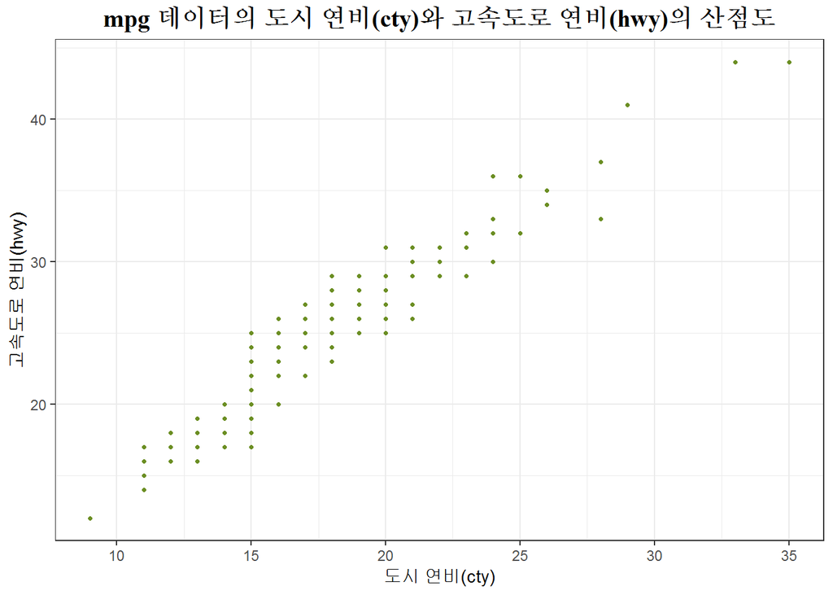

```r
ggplot(mpg,aes(x=cty, y=hwy)) +
  geom_point(size=0.9, color="OliveDrab") +
    theme_bw() +
    labs(x="도시 연비(cty)", y="고속도로 연비(hwy)") +
    ggtitle("mpg 데이터의 도시 연비(cty)와 고속도로 연비(hwy)의 산점도") +
    theme(plot.title = element_text(family = "serif", face = "bold", hjust = 0.5, size = 15, color = "black"))
```

- **문제 2) 미국 지역별 인구통계 정보를 담은 ggplot2 패키지의 midwest 데이터를 이용해서 전체 인구와 아시아인 인구 간에 어떤 관계가 있는지 알아보려고 합니다. x축은 poptotal(전체 인구), y축은 popasian(아시아인 인구)으로 된 산점도를 만들어 보세요. 전체 인구는 50만 명 이하, 아시아인 인구는 1만 명 이하인 지역만 산점도에 표시되게 설정하세요.**

```r
str(midwest)
```

```
## Classes 'tbl_df', 'tbl' and 'data.frame':    437 obs. of  28 variables:
##  $ PID                 : int  561 562 563 564 565 566 567 568 569 570 ...
##  $ county              : chr  "ADAMS" "ALEXANDER" "BOND" "BOONE" ...
##  $ state               : chr  "IL" "IL" "IL" "IL" ...
##  $ area                : num  0.052 0.014 0.022 0.017 0.018 0.05 0.017 0.027 0.024 0.058 ...
##  $ poptotal            : int  66090 10626 14991 30806 5836 35688 5322 16805 13437 173025 ...
##  $ popdensity          : num  1271 759 681 1812 324 ...
##  $ popwhite            : int  63917 7054 14477 29344 5264 35157 5298 16519 13384 146506 ...
##  $ popblack            : int  1702 3496 429 127 547 50 1 111 16 16559 ...
##  $ popamerindian       : int  98 19 35 46 14 65 8 30 8 331 ...
##  $ popasian            : int  249 48 16 150 5 195 15 61 23 8033 ...
##  $ popother            : int  124 9 34 1139 6 221 0 84 6 1596 ...
##  $ percwhite           : num  96.7 66.4 96.6 95.3 90.2 ...
##  $ percblack           : num  2.575 32.9 2.862 0.412 9.373 ...
##  $ percamerindan       : num  0.148 0.179 0.233 0.149 0.24 ...
##  $ percasian           : num  0.3768 0.4517 0.1067 0.4869 0.0857 ...
##  $ percother           : num  0.1876 0.0847 0.2268 3.6973 0.1028 ...
##  $ popadults           : int  43298 6724 9669 19272 3979 23444 3583 11323 8825 95971 ...
##  $ perchsd             : num  75.1 59.7 69.3 75.5 68.9 ...
##  $ percollege          : num  19.6 11.2 17 17.3 14.5 ...
##  $ percprof            : num  4.36 2.87 4.49 4.2 3.37 ...
##  $ poppovertyknown     : int  63628 10529 14235 30337 4815 35107 5241 16455 13081 154934 ...
##  $ percpovertyknown    : num  96.3 99.1 95 98.5 82.5 ...
##  $ percbelowpoverty    : num  13.15 32.24 12.07 7.21 13.52 ...
##  $ percchildbelowpovert: num  18 45.8 14 11.2 13 ...
##  $ percadultpoverty    : num  11.01 27.39 10.85 5.54 11.14 ...
##  $ percelderlypoverty  : num  12.44 25.23 12.7 6.22 19.2 ...
##  $ inmetro             : int  0 0 0 1 0 0 0 0 0 1 ...
##  $ category            : chr  "AAR" "LHR" "AAR" "ALU" ...
```

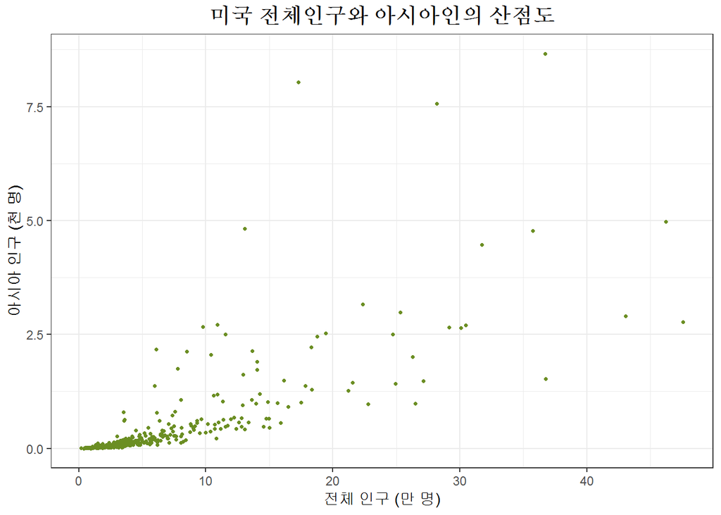

```r
midwest %>% filter(poptotal <= 500000) %>%
            filter(popasian <= 10000) %>%
  ggplot(aes(x=poptotal/10000, y=popasian/1000)) +
  geom_point(size=0.9, color="OliveDrab") +
    theme_bw() +
    labs(x="전체 인구 (만 명)", y="아시아 인구 (천 명)") +
    ggtitle("미국 전체인구와 아시아인의 산점도") +
    theme(plot.title = element_text(family = "serif", face = "bold", hjust = 0.5, size = 15, color = "black"))
```

- **문제 3) 어떤 회사에서 생산한 “suv” 차종의 도시 연비가 높은지 알아보려고 합니다. “suv” 차종을 대상으로 평균 cty(도시 연비)가 가장 높은 회사 다섯 곳을 막대 그래프로 표현해 보세요. 막대는 연비가 높은 순으로 정렬하세요.**

```r
str(mpg)
```

```
## Classes 'tbl_df', 'tbl' and 'data.frame':    234 obs. of  11 variables:
##  $ manufacturer: chr  "audi" "audi" "audi" "audi" ...
##  $ model       : chr  "a4" "a4" "a4" "a4" ...
##  $ displ       : num  1.8 1.8 2 2 2.8 2.8 3.1 1.8 1.8 2 ...
##  $ year        : int  1999 1999 2008 2008 1999 1999 2008 1999 1999 2008 ...
##  $ cyl         : int  4 4 4 4 6 6 6 4 4 4 ...
##  $ trans       : chr  "auto(l5)" "manual(m5)" "manual(m6)" "auto(av)" ...
##  $ drv         : chr  "f" "f" "f" "f" ...
##  $ cty         : int  18 21 20 21 16 18 18 18 16 20 ...
##  $ hwy         : int  29 29 31 30 26 26 27 26 25 28 ...
##  $ fl          : chr  "p" "p" "p" "p" ...
##  $ class       : chr  "compact" "compact" "compact" "compact" ...
```

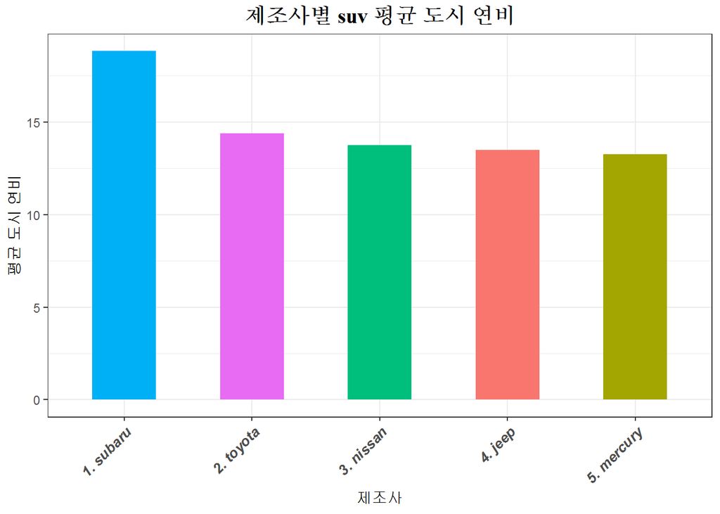

```r
filter(mpg, class=="suv") %>%
  group_by(manufacturer) %>%
  summarise(mean_cty = mean(cty)) %>%
  arrange(desc(mean_cty)) %>% head(5) %>%
    ggplot(aes(x=paste0(1:5,". ",manufacturer), y=mean_cty, fill=manufacturer)) +
    geom_bar(stat = "identity", width = 0.5) +
      labs(x="제조사", y="평균 도시 연비") +
      theme_bw() +
      theme(legend.position = "none") + # 범례 삭제
      theme(axis.text.x = element_text(angle=45, hjust=1, vjust=1, size = 10, face = "bold.italic")) +
      ggtitle("제조사별 suv 평균 도시 연비") +
      theme(plot.title = element_text(family = "serif", face = "bold", hjust = 0.5, size = 15, color = "black"))
```

- **문제 4) 자동차 중에서 어떤 class(자동차 종류)가 가장 많은지 알아보려고 합니다. 자동차 종류별 빈도를 표현한 막대 그래프를 만들어 보세요.**

```r
str(mpg)
```

```
## Classes 'tbl_df', 'tbl' and 'data.frame':    234 obs. of  11 variables:
##  $ manufacturer: chr  "audi" "audi" "audi" "audi" ...
##  $ model       : chr  "a4" "a4" "a4" "a4" ...
##  $ displ       : num  1.8 1.8 2 2 2.8 2.8 3.1 1.8 1.8 2 ...
##  $ year        : int  1999 1999 2008 2008 1999 1999 2008 1999 1999 2008 ...
##  $ cyl         : int  4 4 4 4 6 6 6 4 4 4 ...
##  $ trans       : chr  "auto(l5)" "manual(m5)" "manual(m6)" "auto(av)" ...
##  $ drv         : chr  "f" "f" "f" "f" ...
##  $ cty         : int  18 21 20 21 16 18 18 18 16 20 ...
##  $ hwy         : int  29 29 31 30 26 26 27 26 25 28 ...
##  $ fl          : chr  "p" "p" "p" "p" ...
##  $ class       : chr  "compact" "compact" "compact" "compact" ...
```

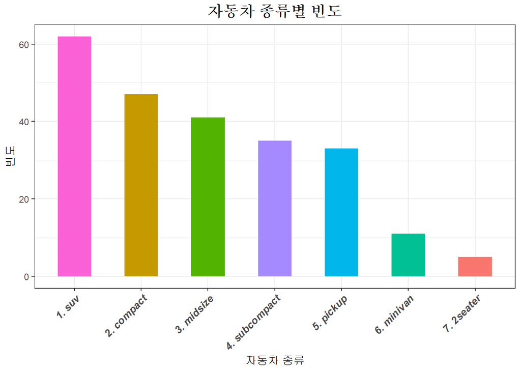

```r
mpg %>%
  select(class) %>%
  group_by(class) %>%
  summarise(n = n()) %>%
  arrange(desc(n)) %>%
    ggplot(aes(x=paste0(1:7,". ",class), y=n, fill=class)) +
    geom_bar(stat = "identity", width = 0.5) +
      labs(x="자동차 종류", y="빈도") +
      theme_bw() +
      theme(legend.position = "none") + # 범례 삭제
      theme(axis.text.x = element_text(angle=45, hjust=1, vjust=1, size = 10, face = "bold.italic")) +
      ggtitle("자동차 종류별 빈도") +
      theme(plot.title = element_text(family = "serif", face = "bold", hjust = 0.5, size = 15, color = "black"))
```

```r
str(economics)
```

```
## Classes 'tbl_df', 'tbl' and 'data.frame':    574 obs. of  6 variables:
##  $ date    : Date, format: "1967-07-01" "1967-08-01" ...
##  $ pce     : num  507 510 516 513 518 ...
##  $ pop     : int  198712 198911 199113 199311 199498 199657 199808 199920 200056 200208 ...
##  $ psavert : num  12.5 12.5 11.7 12.5 12.5 12.1 11.7 12.2 11.6 12.2 ...
##  $ uempmed : num  4.5 4.7 4.6 4.9 4.7 4.8 5.1 4.5 4.1 4.6 ...
##  $ unemploy: int  2944 2945 2958 3143 3066 3018 2878 3001 2877 2709 ...
```

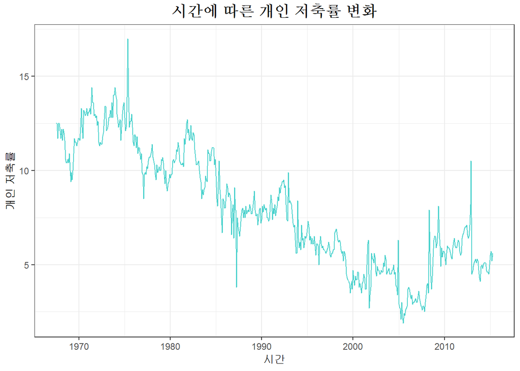

```r
ggplot(economics, aes(x=date, y=psavert)) +
  geom_line(color="MediumTurquoise") +
    theme_bw() +
    labs(x="시간",y="개인 저축률") +
    ggtitle("시간에 따른 개인 저축률 변화") +
    theme(plot.title = element_text(family = "serif", face = "bold", hjust = 0.5, size = 15, color = "black"))
```

- **문제 6) class(자동차 종류)가 “compact”, “subcompact”, “suv”인 자동차의 cty(도시 연비)가 어떻게 다른지 비교해보려고 합니다. 세 차종의 cty를 나타낸 상자 그림을 만들어보세요.**

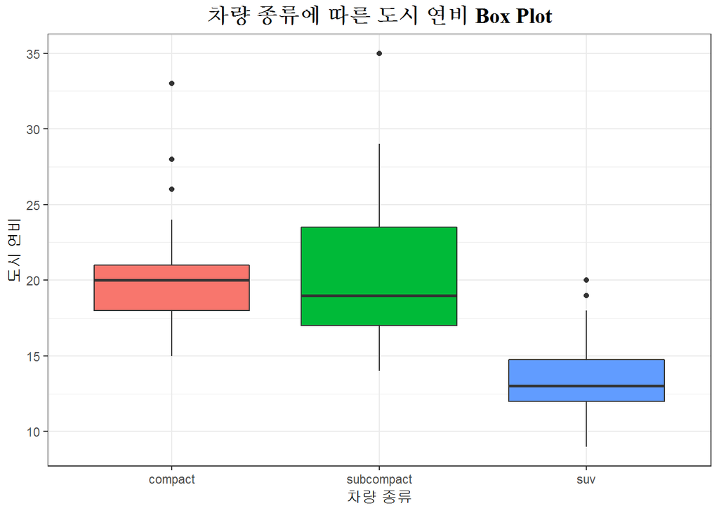

```r
mpg %>%
  select(cty, class) %>%
  filter(class %in% c("compact","subcompact","suv")) %>%
  group_by(class) %>%
    ggplot(aes(x=class, y=cty, fill=class)) +
    geom_boxplot() +
      theme_bw() +
      theme(legend.position = "none") + # 범례삭제
      labs(x="차량 종류",y="도시 연비") +
      ggtitle("차량 종류에 따른 도시 연비 Box Plot") +
      theme(plot.title = element_text(family = "serif", face = "bold", hjust = 0.5, size = 15, color = "black"))
```

- **문제 7) Diamonds 데이터 셋을 이용하여 다음 문제를 해결하세요. 단, 컬러, 제목, x축, y축 등 그래프를 예쁘게 작성하세요.**

```r
str(diamonds)
```

```
## Classes 'tbl_df', 'tbl' and 'data.frame':    53940 obs. of  10 variables:
##  $ carat  : num  0.23 0.21 0.23 0.29 0.31 0.24 0.24 0.26 0.22 0.23 ...
##  $ cut    : Ord.factor w/ 5 levels "Fair"<"Good"<..: 5 4 2 4 2 3 3 3 1 3 ...
##  $ color  : Ord.factor w/ 7 levels "D"<"E"<"F"<"G"<..: 2 2 2 6 7 7 6 5 2 5 ...
##  $ clarity: Ord.factor w/ 8 levels "I1"<"SI2"<"SI1"<..: 2 3 5 4 2 6 7 3 4 5 ...
##  $ depth  : num  61.5 59.8 56.9 62.4 63.3 62.8 62.3 61.9 65.1 59.4 ...
##  $ table  : num  55 61 65 58 58 57 57 55 61 61 ...
##  $ price  : int  326 326 327 334 335 336 336 337 337 338 ...
##  $ x      : num  3.95 3.89 4.05 4.2 4.34 3.94 3.95 4.07 3.87 4 ...
##  $ y      : num  3.98 3.84 4.07 4.23 4.35 3.96 3.98 4.11 3.78 4.05 ...
##  $ z      : num  2.43 2.31 2.31 2.63 2.75 2.48 2.47 2.53 2.49 2.39 ...
```

[output not shown]

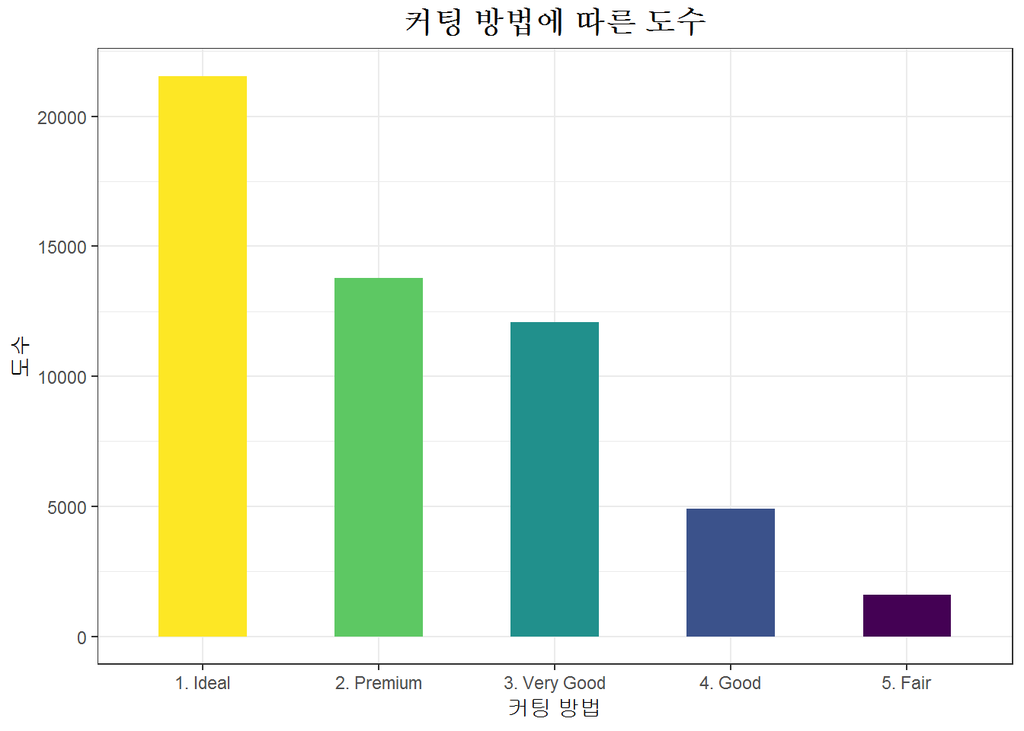

```r
diamonds %>%
  group_by(cut) %>%
  summarise(n = n()) %>%
  arrange(desc(n)) %>%
    ggplot(aes(x=paste0(1:5,". ",cut), y=n, fill=cut)) +
    geom_bar(stat="identity", width = 0.5) +
      theme_bw() +
      labs(x="커팅 방법", y="도수") +
      ggtitle("커팅 방법에 따른 도수") +
      theme(plot.title = element_text(family = "serif", face = "bold", hjust = 0.5, size = 15, color = "black")) +
      theme(legend.position = "none")
```

- **문제 7-2) cut에 따른 가격의 변화를 보여주는 그래프를 작성하세요.**

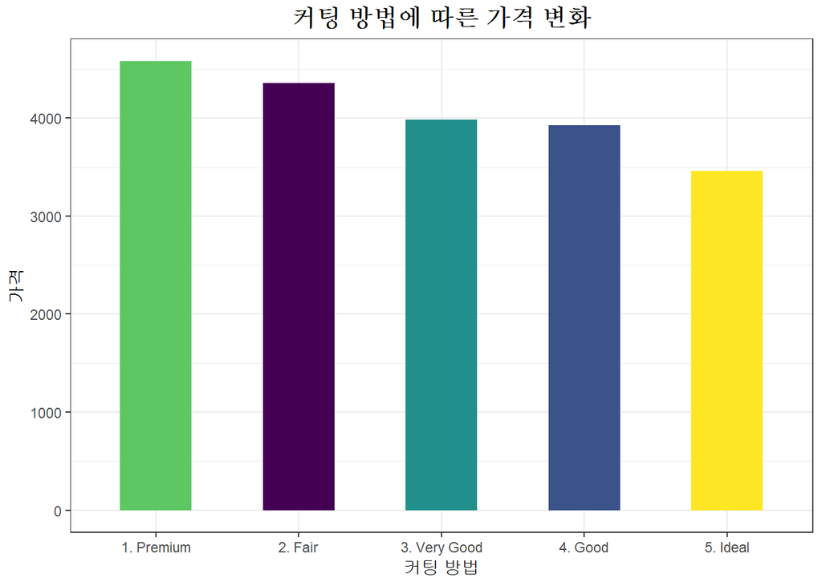

```r
diamonds %>%
  group_by(cut) %>%
  summarise(mean_cut_price = mean(price)) %>%
  arrange(desc(mean_cut_price)) %>%
    ggplot(aes(x=paste0(1:5,". ",cut), y=mean_cut_price, fill=cut)) +
    geom_bar(stat="identity", width = 0.5) +
      theme_bw() +
      labs(x="커팅 방법", y="가격") +
      theme(legend.position = "none") +
      ggtitle("커팅 방법에 따른 가격 변화") +
      theme(plot.title = element_text(family = "serif", face = "bold", hjust = 0.5, size = 15, color = "black"))
```

- **문제 7-3) cut과 color에 따른 가격의 변화를 보여주는 그래프를 작성하세요.**

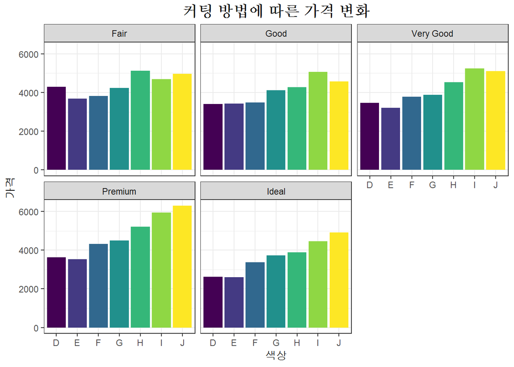

```r
diamonds %>%
  group_by(cut,color) %>%
  summarise(mean_cut_color_price = mean(price)) %>%
  arrange(desc(mean_cut_color_price)) %>%
    ggplot(aes(x=color, y=mean_cut_color_price, fill=color)) +
    geom_bar(stat="identity") +
      facet_wrap(~cut) +
      theme_bw() +
      labs(x="색상", y="가격") +
      theme(legend.position = "none") +
      ggtitle("커팅 방법에 따른 가격 변화") +
      theme(plot.title = element_text(family = "serif", face = "bold", hjust = 0.5, size = 15, color = "black"))
```